# **TikTok Project EDA**

The dataset in this project comes from TikTok and was modified by Google for their Advanced Data Analytics Course.

**1.** Imports

**2.** Data Exploration

**3.** Visualizations

**4.** Conclusion

## **1. Imports**

```python
import pandas as pd
import numpy as np
import matplotlib.pyplot as plt
import seaborn as sns
```

```python
df = pd.read_csv('../CSVs/tiktok_dataset.csv')
```

## **2. Data Exploration**

```python
df.head()
```

|  | # | claim_status | video_id | video_duration_sec | video_transcription_text | verified_status | author_ban_status | video_view_count | video_like_count | video_share_count | video_download_count | video_comment_count |
| --- | --- | --- | --- | --- | --- | --- | --- | --- | --- | --- | --- | --- |
| 0 | 1 | claim | 7017666017 | 59 | someone shared with me that drone deliveries a... | not verified | under review | 343296.0 | 19425.0 | 241.0 | 1.0 | 0.0 |
| 1 | 2 | claim | 4014381136 | 32 | someone shared with me that there are more mic... | not verified | active | 140877.0 | 77355.0 | 19034.0 | 1161.0 | 684.0 |
| 2 | 3 | claim | 9859838091 | 31 | someone shared with me that american industria... | not verified | active | 902185.0 | 97690.0 | 2858.0 | 833.0 | 329.0 |
| 3 | 4 | claim | 1866847991 | 25 | someone shared with me that the metro of st. p... | not verified | active | 437506.0 | 239954.0 | 34812.0 | 1234.0 | 584.0 |
| 4 | 5 | claim | 7105231098 | 19 | someone shared with me that the number of busi... | not verified | active | 56167.0 | 34987.0 | 4110.0 | 547.0 | 152.0 |

```python
df.size
```

```
232584
```

```python
df.shape
```

```
(19382, 12)
```

```python
df.info()
```

```
<class 'pandas.core.frame.DataFrame'>
RangeIndex: 19382 entries, 0 to 19381
Data columns (total 12 columns):
 #   Column                    Non-Null Count  Dtype
---  ------                    --------------  -----
 0   #                         19382 non-null  int64
 1   claim_status              19084 non-null  object
 2   video_id                  19382 non-null  int64
 3   video_duration_sec        19382 non-null  int64
 4   video_transcription_text  19084 non-null  object
 5   verified_status           19382 non-null  object
 6   author_ban_status         19382 non-null  object
 7   video_view_count          19084 non-null  float64
 8   video_like_count          19084 non-null  float64
 9   video_share_count         19084 non-null  float64
 10  video_download_count      19084 non-null  float64
 11  video_comment_count       19084 non-null  float64
dtypes: float64(5), int64(3), object(4)
memory usage: 1.8+ MB
```

```python
df.describe()
```

|  | # | video_id | video_duration_sec | video_view_count | video_like_count | video_share_count | video_download_count | video_comment_count |
| --- | --- | --- | --- | --- | --- | --- | --- | --- |
| count | 19382.000000 | 1.938200e+04 | 19382.000000 | 19084.000000 | 19084.000000 | 19084.000000 | 19084.000000 | 19084.000000 |
| mean | 9691.500000 | 5.627454e+09 | 32.421732 | 254708.558688 | 84304.636030 | 16735.248323 | 1049.429627 | 349.312146 |
| std | 5595.245794 | 2.536440e+09 | 16.229967 | 322893.280814 | 133420.546814 | 32036.174350 | 2004.299894 | 799.638865 |
| min | 1.000000 | 1.234959e+09 | 5.000000 | 20.000000 | 0.000000 | 0.000000 | 0.000000 | 0.000000 |
| 25% | 4846.250000 | 3.430417e+09 | 18.000000 | 4942.500000 | 810.750000 | 115.000000 | 7.000000 | 1.000000 |
| 50% | 9691.500000 | 5.618664e+09 | 32.000000 | 9954.500000 | 3403.500000 | 717.000000 | 46.000000 | 9.000000 |
| 75% | 14536.750000 | 7.843960e+09 | 47.000000 | 504327.000000 | 125020.000000 | 18222.000000 | 1156.250000 | 292.000000 |
| max | 19382.000000 | 9.999873e+09 | 60.000000 | 999817.000000 | 657830.000000 | 256130.000000 | 14994.000000 | 9599.000000 |

## **3. Visualizations**

#### **video_duration_sec**

```python
color = 'pink'
```

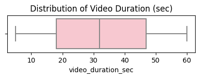

```python
plt.figure(figsize = (5, 1))
sns.boxplot(x = df['video_duration_sec'], color = color).set_title('Distribution of Video Duration (sec)');
```

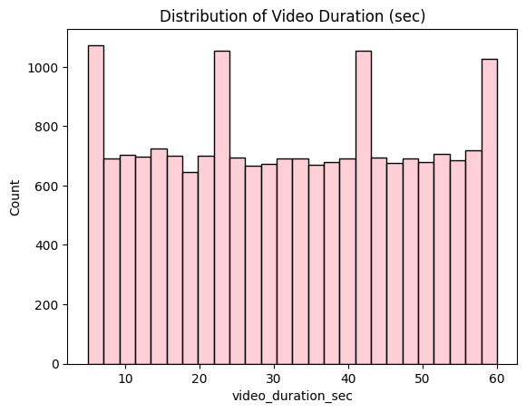

```python
sns.histplot(df, x = 'video_duration_sec', color = color).set_title('Distribution of Video Duration (sec)');
```

#### **video_view_count**

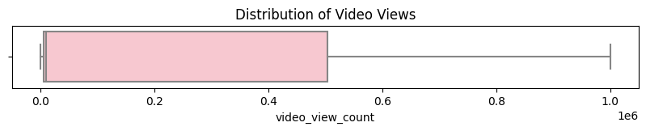

```python
plt.figure(figsize = (10, 1))
sns.boxplot(x = df['video_view_count'], color = color).set_title('Distribution of Video Views');
```

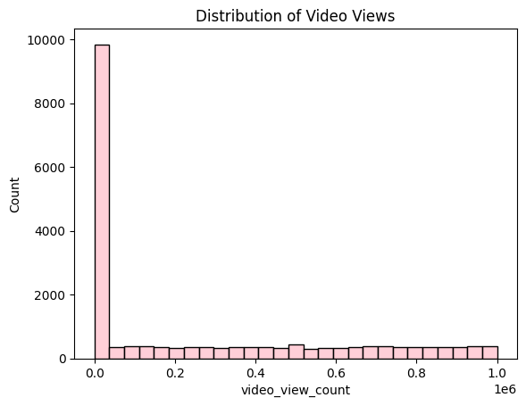

```python
sns.histplot(df, x = 'video_view_count', color = color).set_title('Distribution of Video Views');
```

- Distribution becomes uniform once a video has over ~100,000 views

#### **video_like_count**

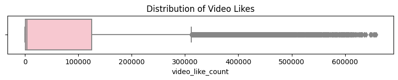

```python
plt.figure(figsize = (10, 1))
sns.boxplot(x = df['video_like_count'], color = color).set_title('Distribution of Video Likes');
```

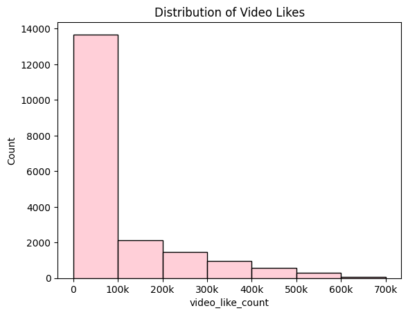

```python
ax = sns.histplot(df, x = 'video_like_count', color = color,
             bins = range(0, (7*10**5+1), 10**5))
labels = [0] + [str(i) + 'k' for i in range(100, 701, 100)]
ax.set_xticks(range(0, 7*10**5+1, 10**5), labels = labels)

plt.title('Distribution of Video Likes');
```

#### **video_comment_count**

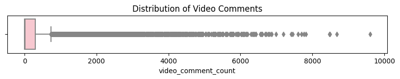

```python
plt.figure(figsize = (10, 1))
sns.boxplot(x = df['video_comment_count'], color = color).set_title('Distribution of Video Comments');
```

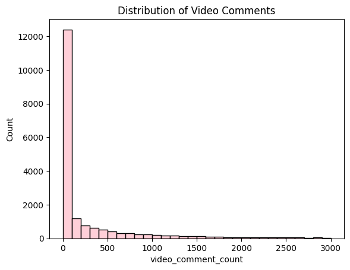

```python
sns.histplot(df, x = 'video_comment_count', color = color,
             bins = range(0, (3001), 100)).set_title('Distribution of Video Comments');
```

- Most videos have less than 100 comments

#### **video_share_count**

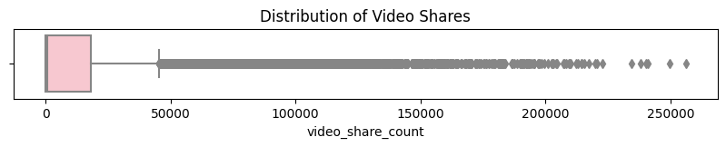

```python
plt.figure(figsize = (10, 1))
sns.boxplot(x = df['video_share_count'], color = color).set_title('Distribution of Video Shares');
```

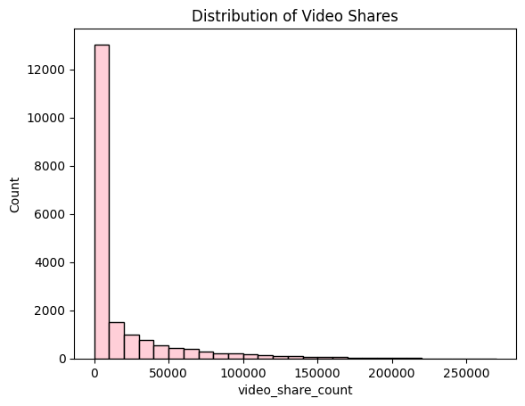

```python
sns.histplot(df, x = 'video_share_count', color = color,
             bins = range(0, (270001), 10000)).set_title('Distribution of Video Shares');
```

- Most videos have less than 10,000 shares

#### **video_download_count**

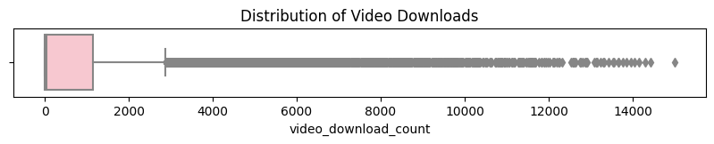

```python
plt.figure(figsize = (10, 1))
sns.boxplot(x = df['video_download_count'], color = color).set_title('Distribution of Video Downloads');
```

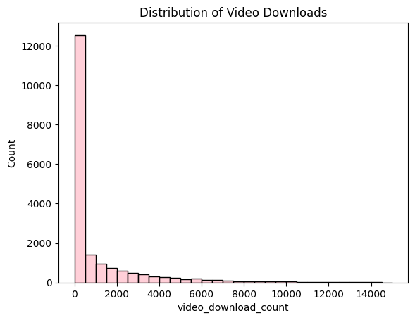

```python
sns.histplot(df, x = 'video_download_count', color = color,
             bins = range(0, (15001), 500)).set_title('Distribution of Video Downloads');
```

#### **Claim status by verification status**

```python
pink = '#FFB6C1'
blue = '#336699'
orange = '#FFA500'
```

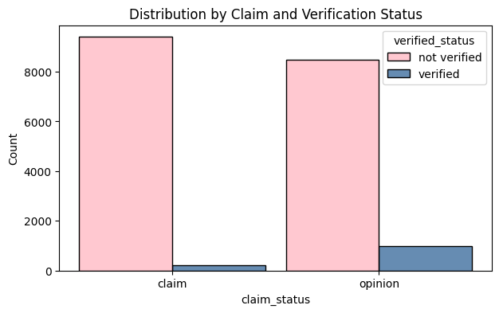

```python
plt.figure(figsize = (7, 4))
sns.histplot(data = df, x = 'claim_status', hue = 'verified_status',
             multiple = "dodge", shrink = 0.9,
             palette = [pink, blue])
plt.title('Distribution by Claim and Verification Status')
plt.show()
```

- Verified users post more videos with opinions than with claims. Unverified users post more videos with claims than with opinions. This discrepancy is higher in verified users.

#### **Claim status by author ban status**

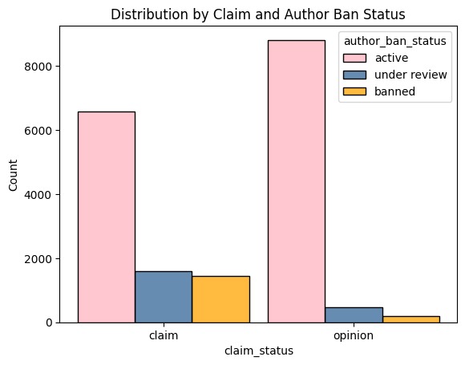

```python
sns.histplot(data = df, x = 'claim_status', hue = 'author_ban_status',
             multiple = 'dodge', shrink = 0.9,
             hue_order = ['active', 'under review', 'banned'],
             palette = [pink, blue, orange])
plt.title('Distribution by Claim and Author Ban Status')
plt.show()
```

- Claims:
  - under review and banned have similar counts
  - active count is much higher
- Opinions:
  - under review count is roughly 2x more than banned count
  - active count is highest out of all categories

#### **Median view counts by ban status**

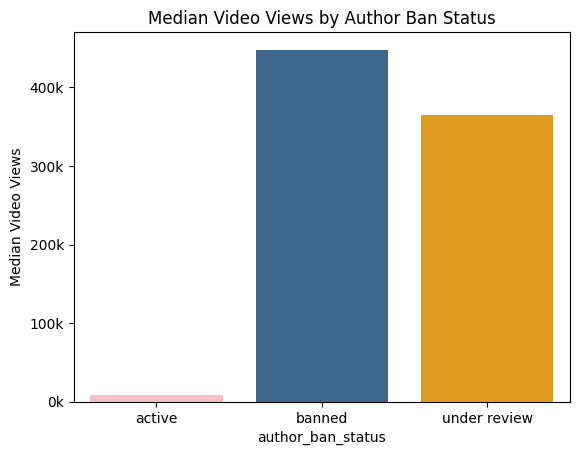

```python
median_views = df.groupby(['author_ban_status']).median(numeric_only = True).reset_index()

ax = sns.barplot(x = 'author_ban_status', y = 'video_view_count', data = median_views,
                 palette = [pink, blue, orange])
plt.title('Median Video Views by Author Ban Status')
plt.ylabel('Median Video Views')

labels = [f'{int(val/1000)}k' for val in ax.get_yticks()]
ax.set_yticklabels(labels)

plt.show();
```

- Authors that are under review or banned have much higher median view counts than active authors.

#### **Median view counts by claim status**

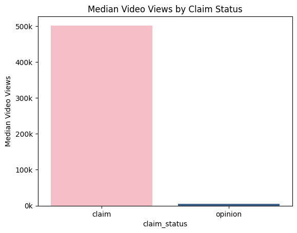

```python
median_views = df.groupby('claim_status')['video_view_count'].median().reset_index()

ax = sns.barplot(x = 'claim_status', y = 'video_view_count', data = median_views,
                 palette = [pink, blue])
plt.title('Median Video Views by Claim Status')
plt.ylabel('Median Video Views')

labels = [f'{int(val/1000)}k' for val in ax.get_yticks()]
ax.set_yticklabels(labels)

plt.show();
```

- Videos with claims have much higher median view counts than videos with opinions

```python
df.groupby('claim_status')['video_view_count'].median()
```

```
claim_status
claim      501555.0
opinion      4953.0
Name: video_view_count, dtype: float64
```

- This suggests we might be able to use views as a claim status indicator

#### **Total views by claim status**

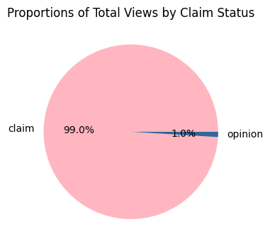

```python
total_views = df.groupby('claim_status')['video_view_count'].sum()

plt.figure(figsize = (4, 4))
plt.pie(total_views, labels = total_views.index, autopct = '%1.1f%%',
        colors = [pink, blue])
plt.title('Proportions of Total Views by Claim Status')
plt.show()
```

- Although there is a relatively equal proportion of claim and opinion videos, 99% of views go to claim videos

#### **Determine outliers**

```python
cols = list(df.columns)[7:]
```

```python
for column in cols:
    Q1 = df[column].quantile(0.25)
    Q3 = df[column].quantile(0.75)

    IQR = Q3 - Q1
    median = df[column].median()

    outlier_threshold = median + 1.5*IQR
    outlier_count = (df[column] > outlier_threshold).sum()
    print(f'Number of outliers, {column}: {outlier_count}')
```

```
Number of outliers, video_view_count: 2343
Number of outliers, video_like_count: 3468
Number of outliers, video_share_count: 3732
Number of outliers, video_download_count: 3733
Number of outliers, video_comment_count: 3882
```

#### **Scatterplot**

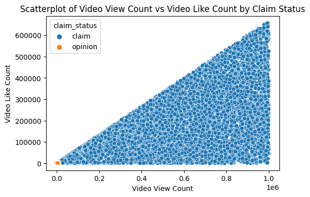

```python
plt.figure(figsize = (6, 4))
sns.scatterplot(x = 'video_view_count', y = 'video_like_count', hue = 'claim_status', data = df)
plt.title('Scatterplot of Video View Count vs Video Like Count by Claim Status')
plt.xlabel('Video View Count')
plt.ylabel('Video Like Count')
plt.show()
```

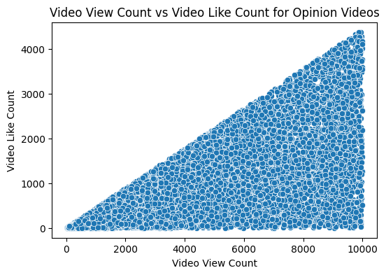

```python
opinion_videos = df[df['claim_status'] == 'opinion']

plt.figure(figsize = (6, 4))
sns.scatterplot(x = 'video_view_count', y='video_like_count', data = opinion_videos)
plt.title('Video View Count vs Video Like Count for Opinion Videos')
plt.xlabel('Video View Count')
plt.ylabel('Video Like Count')
plt.show()
```

## **Conclusion**

- All of the engangement statistics are heavily right skewed, which is to be expected of TikTok data - few videos tend to go viral and receive very high engagement.
- Video view count might be a good indicator of claim status.